# oTree for social scientists

TIBER 2017

## oTree

An open-source platform for lab, web, and field experiments

www.otree.org

[figure not shown]

- **DISCLAIMER**: I'm going to sound like an oTree spokesperson

## Three challenges for social scientists

- interaction between participants
- flexibility in experimental design
- large sample sizes

## EXPLORE

**EX**perimental **P**sychology **L**ab for **O**nline **RE**search  
Startup grant: 90.000 euros

**Team**:

- Ilja van Beest
- Tony Evans
- Me
- Bastian Jaeger
- Joeri Wissink

oTree

## Background

- oTree started in 2013 at ETH Zurich, Daniel Chen group
- Funded by Daniel Chen’s 5-year ERC grant
- Homage to Fischbacher’s z-Tree
- Published paper: http://www.otree.org/oTree.pdf
  - Citation required

## Kinds of studies

- Controlled behavioral experiments in economics, psychology, and related fields
- Multiplayer strategy games, like the prisoner's dilemma, public goods game, and auctions
- Surveys and quizzes

## Concept

- Code your experiment
  - Using Python and Django
- Put it on a server
  - Your university's or hire your own
- Share the link with participants
- Watch the data come in (literally)

Features

## Features

- Free
- Open source
- Beautiful
- **[Admin pane](http://willemsleegers.sohosted-vps.nl:8000/demo/)**

## Features

- Runs on any device

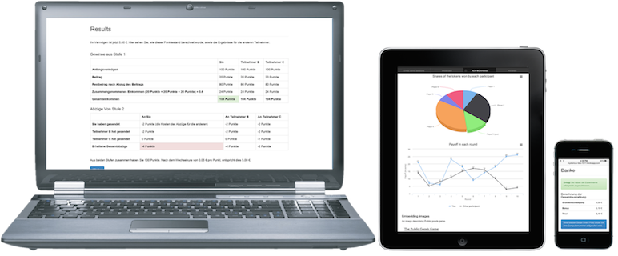

- Monitor studies in real-time

3 key features

## Feature #1: Interaction

- oTree enables true interaction between participants
- Examples: [trust game](http://willemsleegers.sohosted-vps.nl:8000/join/5oqfpcpd48/), [prisoner's dilemma](http://willemsleegers.sohosted-vps.nl:8000/join/xlbo8tsvyq/)

## Feature #2: Flexible

- oTree is open source, therefore completely under your control
- But is also easily expandable without touching core code, for example using Javascript libraries
- Examples: [mouse tracking](http://willemsleegers.sohosted-vps.nl:8000/join/9rkul9ae6e/), [venn task](http://willemsleegers.sohosted-vps.nl:8000/join/rodipx0rcf/), [webcam support](https://arcane-woodland-26076.herokuapp.com/join/weoq4oe8od/)

## Feature #3: Online

- oTree enables complex online studies
- Part of the solution to large sample sizes is to run studies online
- Amazon Mechanical Turk integration
- Example: Bastian's presentation, [personality and trust study](http://willemsleegers.sohosted-vps.nl:8000/join/s94sw0esw5/)

## Limitations

- Dropout
- Screen sizes
- Requires programming

## Required skills

- Setting up a server: let your IT people do this
- Python: [Learn Python the Hard Way](https://learnpythonthehardway.org), [oTree Python Tutorial](http://otree.readthedocs.io/en/latest/python.html)
- Django: [oTree tutorials](http://otree.readthedocs.io/en/latest/tutorial/intro.html)
- oTree: [oTree documentation](http://otree.readthedocs.io/en/latest/index.html), [Mailing list](https://groups.google.com/forum/#!forum/otree)
- HTML, CSS, Javascript: any tutorial, [Stack Overflow](http://stackoverflow.com)

## Conclusion

oTree is a very well-designed platform that can be used to address (at least) three key challenges for social scientists:

- true interaction between participants
- flexible experimental design
- run online studies to acquire large sample sizes